# Tutorial 3 - sorteios e probabilidade

curso de IBMs

## 1 - Descobrindo “MILHÕES” de distribuições

O R já possui de maneira “nativa”, sem a instalação de nenhum pacote adicional, milhões de funções relacionadas a distribuições probabilísticas, entre elas, as funções que geram números aleatórios de acordo com estas distribuições. As funções de geração de número aleatório sempre começam com a letra **r** (de *random*), e você pode ter uma ideia das múltiplas distribuições digitando:

```r
?Distributions
```

Para esse tutorial, nós só nos preocuparemos com quatro distribuições inicialmente: normal, Poisson, normal truncada e binomial.

## 2 - Números aleatórios na distribuição normal

A distribuição normal quase dispensa apresentação, é aquela distribuição em forma de sino que descreve nada e tudo no universo ao mesmo tempo. Números aleatórios na distribuição normal podem ser facilmente gerados usando a função *rnorm()* (verifique o *help* para entender os argumentos da função):

```r
rnorm(10, mean = 4, sd =1)
```

```
##  [1] 4.241101 4.366470 3.980284 3.169929 2.654952 3.805364 4.326557
##  [8] 5.129275 4.956478 3.782899
```

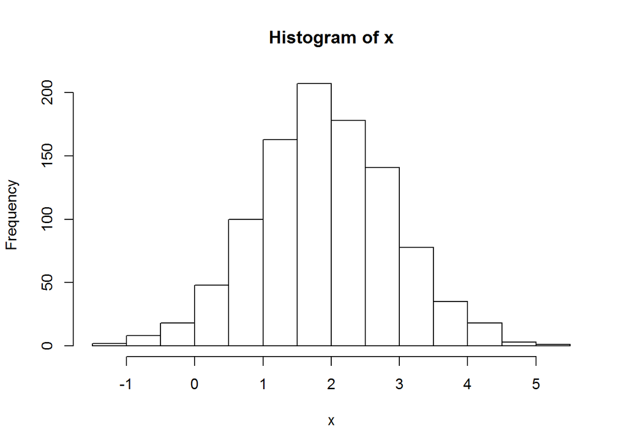

```r
x = rnorm(1000, mean=2, sd=1)
hist(x)
```

## 3 - Mas, esses números são aleatórios mesmo?

Eventualmente, ouvimos alguém se referir aos números aleatórios gerados por computador como pseudo-aleatórios, mas qual a diferença? Seguindo a definição de que aleatório é sinônimo de imprevisível, vamos verificar se successivos sorteios nos dão resultados imprevisíveis:

```r
rnorm(10, mean = 4, sd =1)
```

```
##  [1] 3.599847 5.451484 3.116159 3.220474 3.250923 3.602601 4.416822
##  [8] 4.794533 5.152180 4.159254
```

```r
rnorm(10, mean = 4, sd =1)
```

```
##  [1] 4.387406 4.161216 3.894480 3.643704 3.352573 4.451344 5.610615
##  [8] 3.544816 3.504217 2.783070
```

```r
rnorm(10, mean = 4, sd =1)
```

```
##  [1] 2.449086 4.138879 2.834733 3.862779 2.045937 3.447353 4.304939
##  [8] 5.088910 2.604511 4.160126
```

Embora os valores estejam sempre perto de quatro (afinal nós escolhemos média 4 e desvio padrão 1), os valores individuais são aparentemente imprevisíveis, não tem nada de “pseudo” na aleatoriedade gerada certo? Bem, vamos usar a função *set.seed()* agora:

```r
set.seed(42) #pode ser qualquer número inteiro
rnorm(10, mean = 4, sd =1)
```

```
##  [1] 5.370958 3.435302 4.363128 4.632863 4.404268 3.893875 5.511522
##  [8] 3.905341 6.018424 3.937286
```

```r
#vamos repetir o sorteio agora:
set.seed(42)
rnorm(10, mean = 4, sd =1)
```

```
##  [1] 5.370958 3.435302 4.363128 4.632863 4.404268 3.893875 5.511522
##  [8] 3.905341 6.018424 3.937286
```

MEU DEUS! Agora os números não são mais aleatórios!?

Pois bem, os números nunca foram realmente aleatórios. Sequências de números aleatórios são geradas pelo computador com base em uma semente de números aleatórios (*seed*), e dada uma mesma semente, um computador é capaz de gerar a mesma sequência. Dentro da sequência, porém, cada resultado não contém informação para prever o próximo. Portanto, dentro de uma simulação os números são efetivamente aleatórios (pergunte se a coisa ficou confusa).

Em um conjunto de computadores, normalmente a mesma semente vai gerar dois ou três resultados diferentes (compare o resultado do último comando com o de seu amiguinho). Mas, na mesma máquina, o resultado é sempre o mesmo. E pra que serve isso? Serve para poder reproduzir resultados. Sabendo as sementes de números aleatórios que você usou em um dado conjunto de simulações, é possível reproduzir seus resultados, bit por bit, em uma máquina semelhante.

Por outro lado, se você estivesse fazendo simulações em algum passado longínquo, usando ossos de cabra pra gerar números aleatórios, seus resultados seriam verdadeiramente aleatórios, mas um conjunto de simulações jamais poderia ser reproduzido de maneira exata caso necessário.

# 4 - Distribuição normal truncada

Direto do dicionário, *“Truncado: adj. Incompleto; cujas partes essenciais foram retiradas. Cortado; que foi alvo de mutilação ou corte.”*

A distribuição normal é uma distribuição totalmente sem limites, que vai desde o menos infinito até o mais infinito. A distribuição normal truncada é uma distribuição normal em que pelo menos uma das caudas da distribuição é decepada (!). Isso faz com que ela tenha quatro parâmatros, média, desvio padrão, mínimo e máximo. Se o mínimo e o máximo forem definidos como **-Inf** e **Inf**, a normal truncada se torna uma normal normal.

Números aleatórios dessa distribuição podem ser gerados usando a função *rtruncnorm()* do pacote *truncnorm*. Se você ainda não tem esse pacote em sua máquina, é só instalar com o comando:

```r
install.packages("truncnorm")
```

Com o pacote instalado, é só carregá-lo e usar suas funções. Antes de prosseguir lembre-se de consultar o *help* da função *rtruncnorm()*:

```r
library(truncnorm)

norm = rnorm(n=1000, mean=1, sd=1/2)

klunk = rtruncnorm(n = 1000, a=0, b=2,  mean=1, sd=1/2)

#vamos registrar os limites dos dados em norm
nlim = range(norm) #não conhece a função range()? Consulte o help!
nlim
```

```
## [1] -0.6858695  2.7476521
```

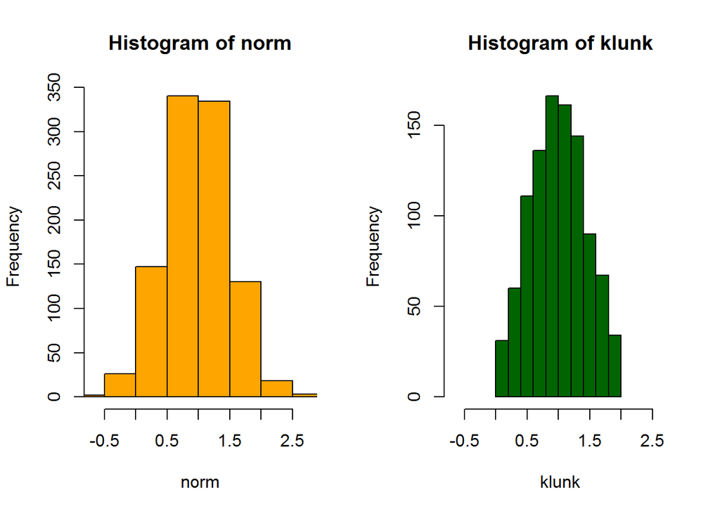

```r
par(mfrow=c(1,2))
hist(norm, xlim = nlim, col="orange")
hist(klunk, xlim= nlim, col="darkgreen")
```

Como você pode ver, a distribuição normal truncada é realmente uma distribuição normal com as caudas cortadas, mas você não precisa cortar as duas caudas, é só estabelecer o mínimo como **-Inf** para “devolver” a cauda esquerda para a distribuição, ou estabelecer o máximo como **Inf** para “devolver” a cauda direita:

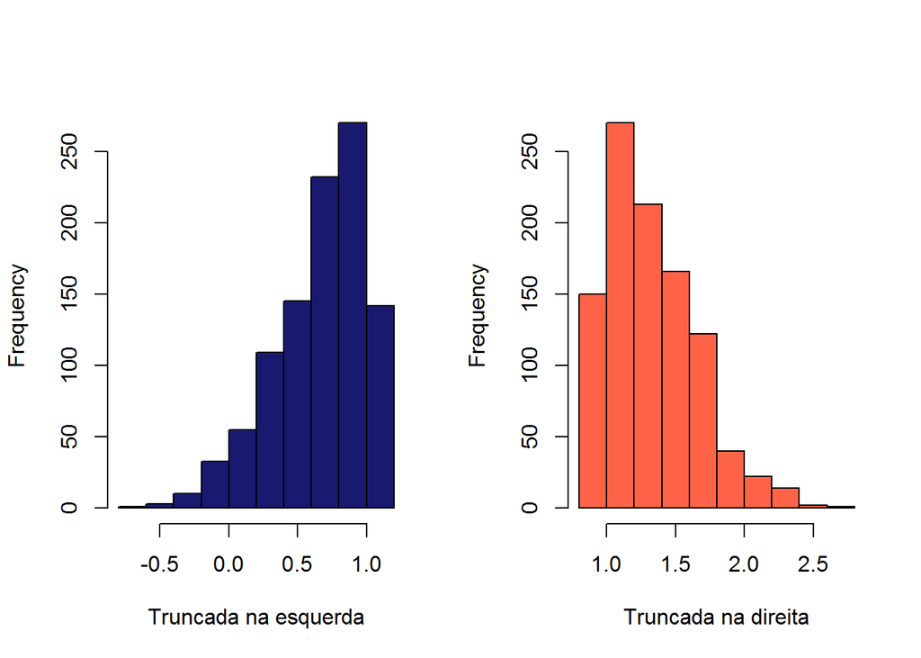

```r
par(mfrow=c(1,2))

hist(rtruncnorm(n = 1000, a=-Inf, b=1.1,  mean=1, sd=1/2), col="midnightblue",
     xlab="Truncada na esquerda", main="")
hist(rtruncnorm(n = 1000, a=0.9, b=Inf,  mean=1, sd=1/2), col="tomato",
     xlab="Truncada na direita", main="")
```

```r
# O R tem uns nomes de cores muito doidos!
```

Você deve estar se perguntando pra que usar essa distribuição “amputada”? A principal razão é poder estabelecer limites para a distribuição de algum valor da sua simulação, existem casos em que não queremos valores negativos ou acima de um certo limite. A distribuição normal truncada não é o único jeito de fazer isso, mas é o único que eu conheço em que a média e o desvio continuam independentes, como na distribuição normal. Além disso, todo mundo conhece a distribuição normal.

### 4.1 - A amputação deixa sequelas!

Uma coisa importante é que a média esperada (ou esperança estatística, pra usarmos o termo mais correto) da distribuição normal truncada, nem sempre é a média que estabelecemos pra ela.Podemos verificar isso fazendo um boxplot com distribuições com a mesma média mas truncadas em pontos diferentes.

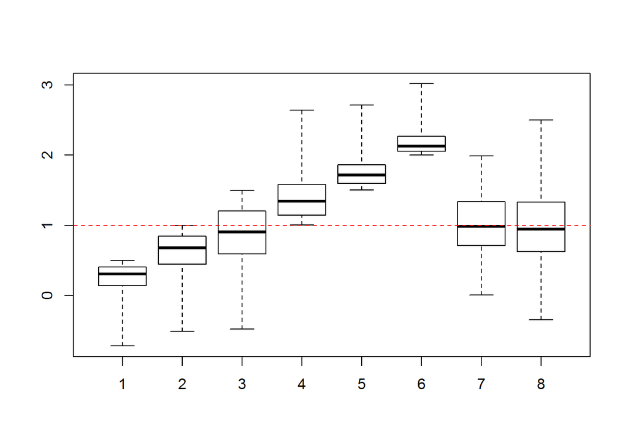

```r
#Vamos começar criando uma matriz
matrizKlunk = matrix(NA, nrow=500, ncol=8)
media = 1
desvio = 1/2
minimos = c(-Inf, -Inf, -Inf,  1,  1.5,  2,  0, -Inf)
maximos = c( 0.5,  1 , 1.5, Inf, Inf, Inf, 2, Inf)

for(i in 1:ncol(matrizKlunk))
  matrizKlunk[,i] = rtruncnorm(500, a=minimos[i], b=maximos[i],
                               mean=media, sd = desvio)

par(mfrow=c(1,1))
boxplot(matrizKlunk, range = 0)
#Com range = 0, os "bigodes" do boxplot vão até o mínimo e máximo dos dados

#Agora vamos adicionar uma linha onde a mediana dos dados deveria estar
abline(h=1, lty=2, col="red")
```

No boxplot dá pra ver que em alguns casos a mediana vai parar bem longe da média que estabelecemos para a distribuição. A mediana fica igual a média quando nós cortamos a distribuição de maneira simétrica, como na sétima coluna da nossa matriz. Calcular o valor esperado para a normal truncada envolve uma fórmula um pouco chata, mas, para a nossa alegria, o pacote *truncnorm* já faz isso pra gente com a função *etruncnorm()*

```r
etruncnorm(a=minimos, b=maximos, mean=media, sd=desvio)
```

```
## [1] 0.2374324 0.6010577 0.8562000 1.3989423 1.7625676 2.1866078 1.0000000
## [8] 1.0000000
```

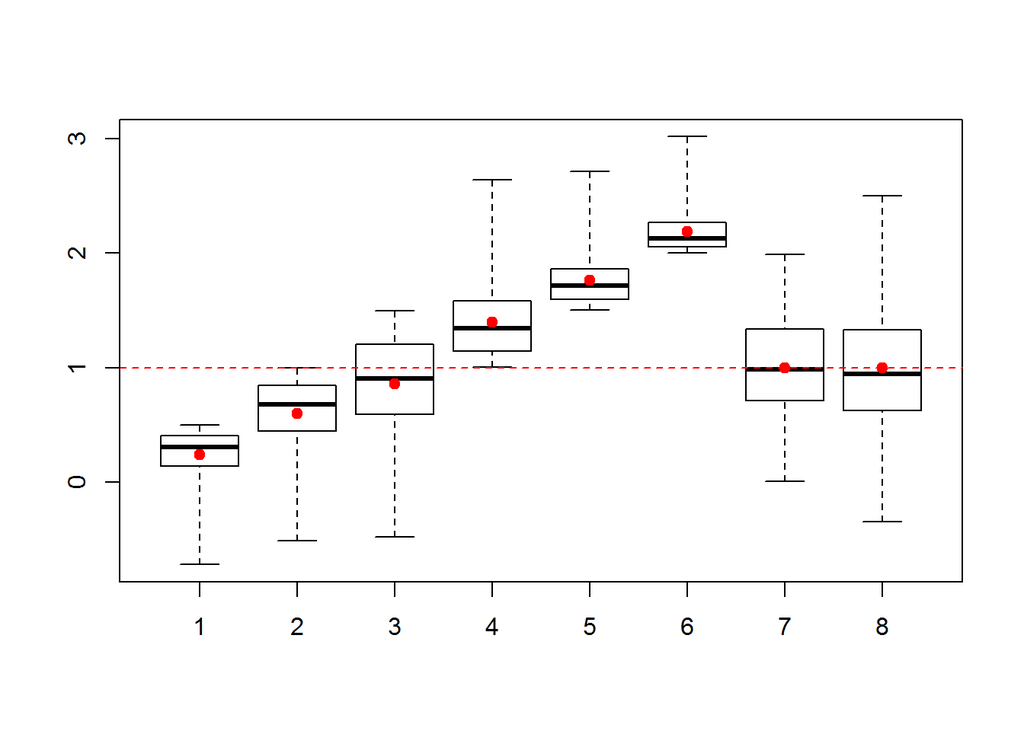

```r
#Vamos adicionar os valores no gráfico?

par(mfrow=c(1,1))
boxplot(matrizKlunk, range = 0)
abline(h=1, lty=2, col="red")
points(x=1:8, y=etruncnorm(a=minimos, b=maximos, mean=media, sd=desvio),
       pch=19, col="red")
```

```r
#Tcharans!
```

## 5 - A distribuição binomial

Podemos gerar valores aleatórios da nossa querida distribuição binomial usando a função *rbinom()*. Como você deve se lembrar, a distribuição binomial descreve o número de sucessos em *n* tentativas (de alguma coisa) com probabilidade de sucesso *p*. É importante lembrar das *n* tentativas, pois isso faz com que a distribuição binomial possa possuir valores diferentes de zero ou um.

Vamos brincar um pouco com a função:

```r
#Na função, size determina o número de sorteios
rbinom(n = 10, size=1, prob = 0.5)
```

```
##  [1] 1 1 0 1 1 0 0 0 0 0
```

Estabelecendo o *n*, ou *size*, como 1, a função *rbinom()* é muito útil para estabelecer o resultado de sorteios binários: o indivíduo sobrevive ou não a alguma coisa? O indivíduo é ou não infectado por um parasita do espaço? Ele coloca o arroz por cima ou por baixo do feijão?

Se seu coração anseia por gráficos da distribuição binomial, sorteie conjuntos de valores com parâmetros diferentes e faça histogramas com a cor **“dodgerblue4”**

### 5.1 - Vivo ou morto?

Vamos fazer uma quase simulação de seleção natural. Vamos supor que temos uma população de indivíduos com um traço fenotípico qualquer que influencia sua sobrevivência, e que esse traço segue uma distribuição normal truncada. Para evitar valores negativos, vamos truncar a distribuição em zero, estabelecer uma média de 3 e desvio padrão 1. Vamos então criar um data.frame, a primeira coluna terá o traço de nossos indivíduos, e a segunda guardará se ele sobrevive ou não à seleção natural. A segunda coluna, inicialmente, será preenchida com NA.

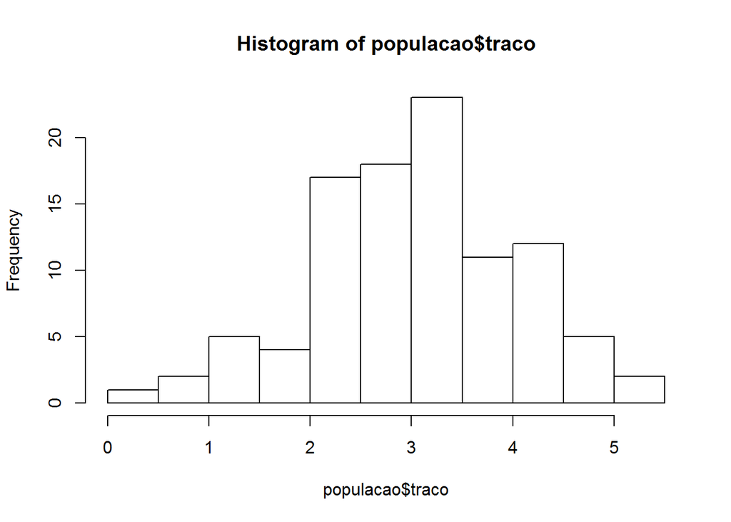

```r
populacao = data.frame(traco = rtruncnorm(100, a=0, mean=3, sd=1), sobrevive = NA)

hist(populacao$traco)
```

Inicialmente, vamos supor que existe seleção direcional, quanto maior o traço de um indivíduo maior a probabilidade dele sobreviver. Para isso, vamos usar a funcão logística inversa que vimos na aula. Com isso, a probabilidade de sobrevivência de um indivíduo é igual a $logit^-1(a + b*x)$, em que *x* é o traço fenotípico.

Vamos começar criando uma função que calcula a logística inversa, ela deve ter três argumentos: x, a e b.

```r
invlogit = function(x, a=0, b=1)
{
  y = a+b*x

  return(exp(y)/(exp(y)+1))
}
```

Podemos fazer um gráfico pra ver se a função está funcionando mesmo:

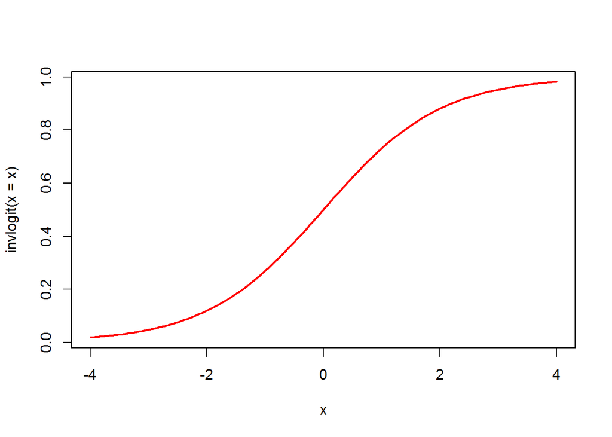

```r
curve(invlogit(x=x), from=-4, to=4, lwd=2, col="red")
```

Funciona!

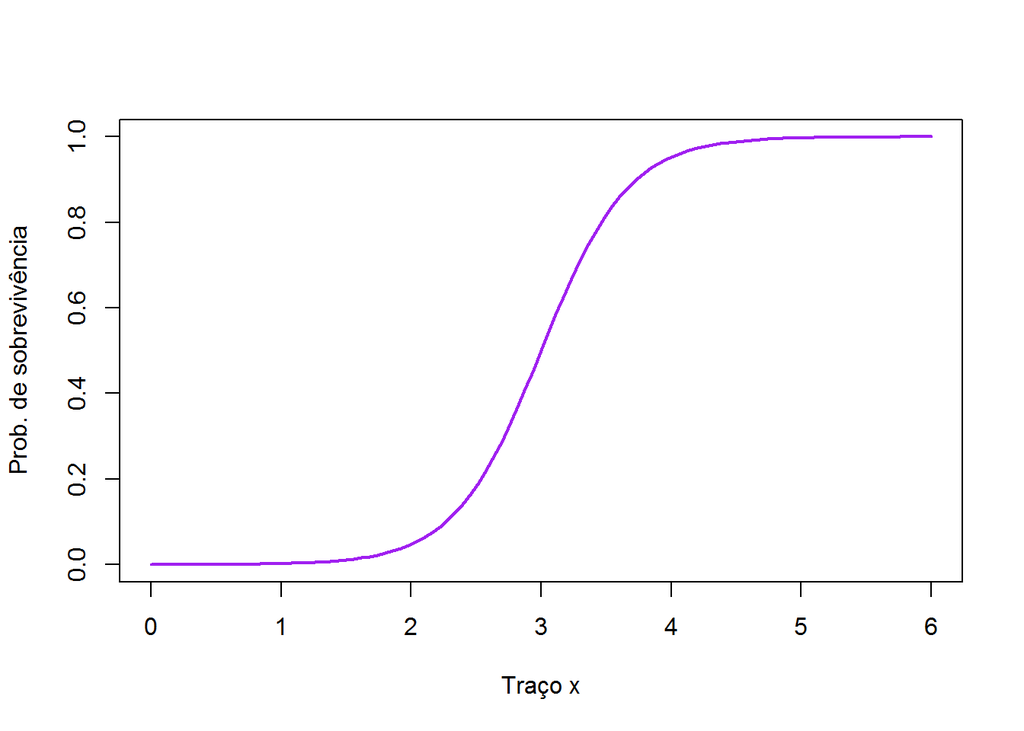

```r
curve(invlogit(x=x, a=-9, b=3), from=0, to=6, lwd=2, col="purple",
      ylab="Prob. de sobrevivência", xlab="Traço x")
```

Agora, podemos decidir quem vive e quem morre usando a função que acabamos de criar e um sorteio binomial. Para efeitos didáticos, primeiro vamos calcular a probabilidade de sobrevivência e salvar em um objeto, e depois vamos fazer o sorteio.

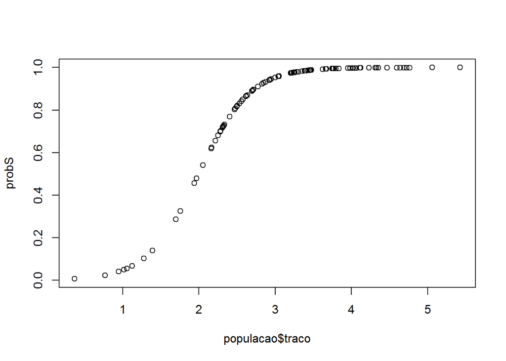

```r
probS = invlogit(x=populacao$traco, a = -6, b = 3)

#E vamos fazer um gráfico pra não perder o hábito
plot(probS~populacao$traco)
```

E agora, podemos sortear:

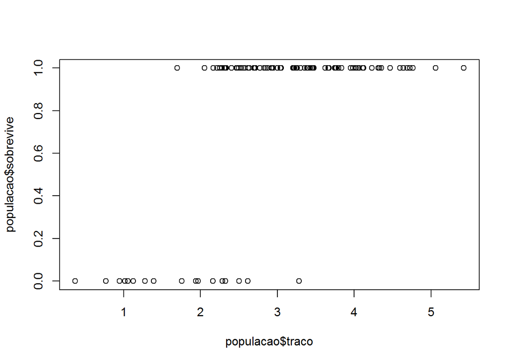

```r
populacao$sobrevive = rbinom(n = 100, size = 1, prob = probS)

#Também podemos fazer um gráfico com isso:

plot(populacao$sobrevive~populacao$traco)
```

### 5.2 - Vivo ou morto, parte II

Agora, suponha que queremos simular a seleção estabilizadora. Para isso, podemos usar a função gaussiana que vimos em aula. Novamente, vamos criar uma pequena função que calcule a probabilidade de sobrevivência em função de *x*. Os outros parâmetros dessa vez são a média e o desvio padrão da curva de sobrevivência, que podemos chamar de *mu* e *sigma*. Nossa função então fica:

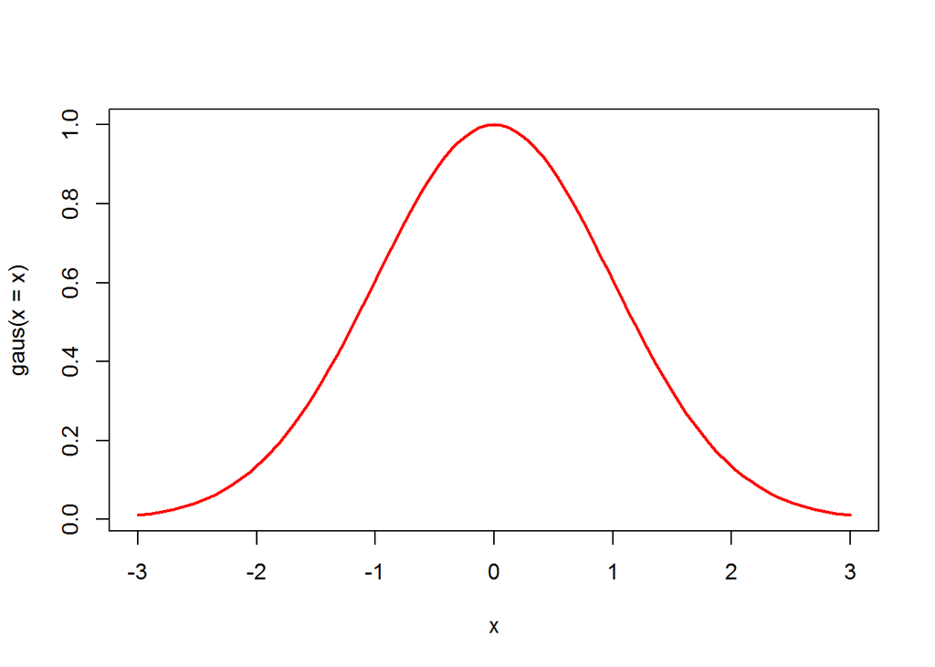

```r
gaus = function(x, mu=0, sigma=1)
{
  return(exp( -((x-mu)^2) / 2*sigma^2))
}

#Nunca se esqueça do gráfico!
curve(gaus(x=x), from=-3, to=3, lwd=2, col="red")
```

Vamos estabelecer então seleção estabilizadora com mu = 3 e sigma = 2. Dessa vez, podemos calcular as probabilidades e fazer o sorteio em um comando só:

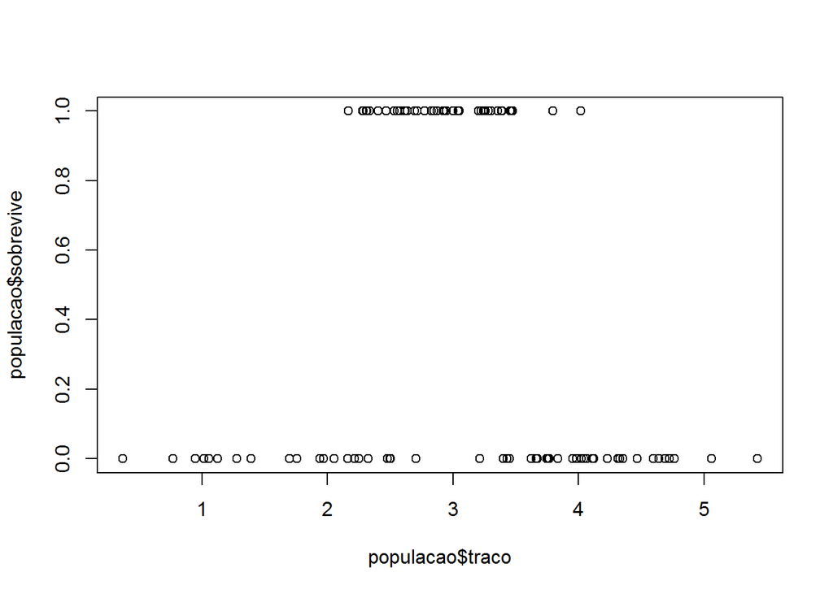

```r
populacao$sobrevive = rbinom(n = 100, size = 1, prob = gaus(x=populacao$traco, mu=3, sigma=2))

plot(populacao$sobrevive~populacao$traco)
```

Você consegue pensar em processos biológicos que podem ser simulados com uma distribuição binomial com o número de sorteios maior do que um?

## 6 - Distribuição Poisson

A distribuição Poisson é uma distribuição que só inclui valores inteiros maiores ou iguais a zero, seu único parâmetro determina tanto a média quanto a variância. Este parâmetro único é chamado tradicionalmente de *lambda*.

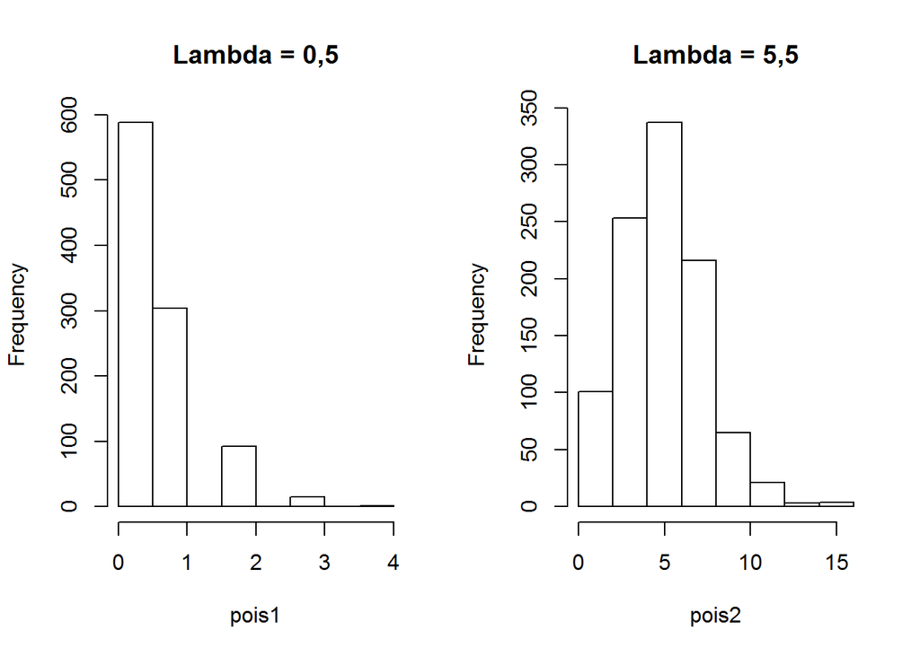

```r
pois1 = rpois(n = 1000, lambda = 0.5)

pois2 = rpois(n = 1000, lambda = 5.5)

par(mfrow=c(1,2))
hist(pois1, main="Lambda = 0,5")
hist(pois2, main="Lambda = 5,5")
```

Como você pode ver, embora a distribuição Poisson só gere números inteiros, o valor de lambda não precisa ser inteiro. Agora que geramos dois conjuntos de valores, verifique se todos os valores são mesmo inteiros e calcule a média e variância de cada conjunto. Estes valores deveriam ser muito próximos de lambda.

## 7 - Distribuição uniforme

Valores aleatórios da distribuição uniforme podem ser criados com a função *runif()*, os argumentos da função especificam o número de valores aleatórios, o mínimo e o máximo.

```r
runif(10, 0, 1)
```

```
##  [1] 0.003612131 0.565161212 0.352667975 0.259532710 0.591795802
##  [6] 0.491605056 0.307715252 0.067848917 0.651100972 0.072125803
```

Esta função é muito útil na hora de estabelecer posições aleatórias dentro de um espaço quadrado (ou retangular):

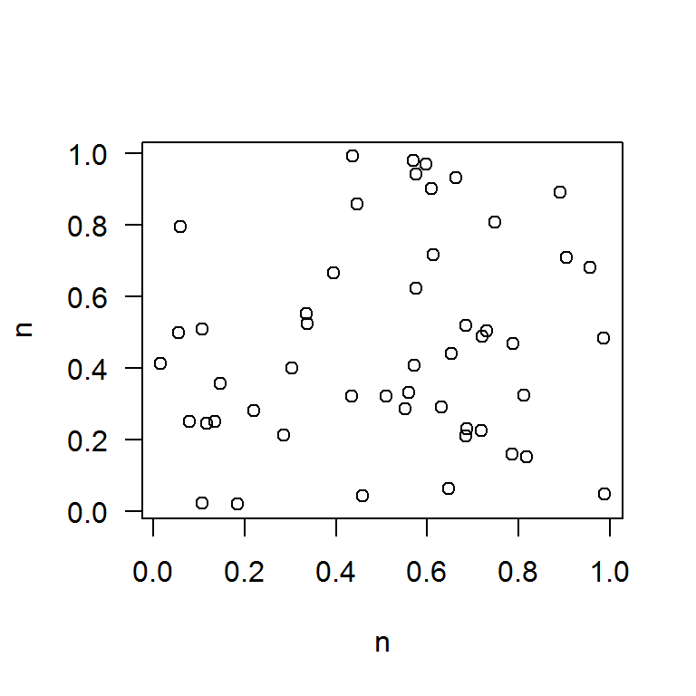

```r
posicoes = cbind(x = runif(50, 0, 1), y = runif(50, 0 , 1))
plot(posicoes, xlab="n", ylab="n", las=1)
```

## 8 - Sorteio e embaralhamento com a função sample

A principal função para sortear quase qualquer coisa no R é a função *sample()*, consulte o *help* da função para aprender mais sobre suas mil e uma funcionalidades, mas, essencialmente o que ela faz é retirar amostras de um vetor. O principal argumento da função é, portanto, o vetor que ela tem que amostrar. Se você simplesmente chamar a função *sample()* e der um vetor a ela, você verá o seguinte:

```r
sample(1:10)
```

```
##  [1]  7  2  1  3 10  6  8  5  9  4
```

O que ela fez foi embaralhar tudo. Se você verificar o *help* da função, descobrirá que ela tem os seguintes argumentos: * x - o vetor do qual a função tirará amostras * size - o número de elementos que deve ser amostrado * replace - o sorteio deve ser feito com ou sem reposição * prob - um vetor de probabilidades, caso alguns resultados sejam mais prováveis que outros

Com tudo isso, já podemos fazer muita coisa!